# Sampangiramaiah_Kuppala_A3_Question4

## Clustering

The goal is to determine among three potential hackers suspected by the company, whether the third hacker is involed in hacking or not.

##### Dataset:

The Dataset "hack_data.csv" contains 334 attack instances with following attributes:

1. Session_Connection_Time
2. Bytes Transferred
3. Kali_Trace_Used
4. Servers_Corrupted
5. Pages_Corrupted
6. Location
7. WPM_Typing_Speed

##### Attribute Description:

1. Session_Connection_Time: It specifies how long the session lasted.
2. Bytes Transferred: It specifies the Megabytes transferred during session
3. Kali_Trace_Used : It specifies whether the hacker was using Kali Linux
4. Servers_Corrupted: It specifies the number of server corrupted during the attack
5. Pages_Corrupted: It specifies the number of pages illegally accessed
6. Location: It specifies the location from where attack has come
7. WPM_Typing_Speed: It specifies the estimated typing speed based on session logs

Location column is discarded because there are chances that hackers would have used VPNs to hide their real locations during the attacks.

All the remaining attributes play a significant role to determine whether third hacker is involved in hacking or not

Note: if attacks are equally divided among two hackers then third hacker is innocent

## Creating SparkSession

Creating SparkSession class, which is entry point to all functionality in Spark.

To create basic SparkSession, SparkSession.builder is used with application name is set to "Clustering"

```python
# Creating SparkSession class which is entry point to all functionality in Spark
# To create basic SparkSession, SparkSession.builder is used.
from pyspark.sql import SparkSession
spark = SparkSession.builder.appName('Clustering').getOrCreate()
```

```python
# import K-means
from pyspark.ml.clustering import KMeans
```

## Load and Review Data

Load the "hack_data.csv" dataset and review it to understand the dataset.

```python
# Read the csv file and create the dataframe(data)
# inferschema=True means SparkSession will automatically detect the datatype of each column in data frame
# header = True means csv files contains the header
data = spark.read.csv('hack_data.csv',inferSchema=True,header=True)
```

```python
# PrintSchema() is used to see data types of columns in dataframe which prints schema in tree method
data.printSchema()
```

```
root
 |-- Session_Connection_Time: double (nullable = true)
 |-- Bytes Transferred: double (nullable = true)
 |-- Kali_Trace_Used: integer (nullable = true)
 |-- Servers_Corrupted: double (nullable = true)
 |-- Pages_Corrupted: double (nullable = true)
 |-- Location: string (nullable = true)
 |-- WPM_Typing_Speed: double (nullable = true)
```

```python
# Displays the content of Data frame
data.show(5)
```

```
+-----------------------+-----------------+---------------+-----------------+---------------+--------------------+----------------+
|Session_Connection_Time|Bytes Transferred|Kali_Trace_Used|Servers_Corrupted|Pages_Corrupted|            Location|WPM_Typing_Speed|
+-----------------------+-----------------+---------------+-----------------+---------------+--------------------+----------------+
|                    8.0|           391.09|              1|             2.96|            7.0|            Slovenia|           72.37|
|                   20.0|           720.99|              0|             3.04|            9.0|British Virgin Is...|           69.08|
|                   31.0|           356.32|              1|             3.71|            8.0|             Tokelau|           70.58|
|                    2.0|           228.08|              1|             2.48|            8.0|             Bolivia|            70.8|
|                   20.0|            408.5|              0|             3.57|            8.0|                Iraq|           71.28|
+-----------------------+-----------------+---------------+-----------------+---------------+--------------------+----------------+
only showing top 5 rows
```

```python
# head() is used to see first n observations
data.head(5)
```

```
[Row(Session_Connection_Time=8.0, Bytes Transferred=391.09, Kali_Trace_Used=1, Servers_Corrupted=2.96, Pages_Corrupted=7.0, Location='Slovenia', WPM_Typing_Speed=72.37),
 Row(Session_Connection_Time=20.0, Bytes Transferred=720.99, Kali_Trace_Used=0, Servers_Corrupted=3.04, Pages_Corrupted=9.0, Location='British Virgin Islands', WPM_Typing_Speed=69.08),
 Row(Session_Connection_Time=31.0, Bytes Transferred=356.32, Kali_Trace_Used=1, Servers_Corrupted=3.71, Pages_Corrupted=8.0, Location='Tokelau', WPM_Typing_Speed=70.58),
 Row(Session_Connection_Time=2.0, Bytes Transferred=228.08, Kali_Trace_Used=1, Servers_Corrupted=2.48, Pages_Corrupted=8.0, Location='Bolivia', WPM_Typing_Speed=70.8),
 Row(Session_Connection_Time=20.0, Bytes Transferred=408.5, Kali_Trace_Used=0, Servers_Corrupted=3.57, Pages_Corrupted=8.0, Location='Iraq', WPM_Typing_Speed=71.28)]
```

```python
# describe operation is use to calculate the summary statistics of numerical column(s) in DataFrame 'data'.
data.describe().show()
```

```
+-------+-----------------------+------------------+------------------+-----------------+------------------+-----------+------------------+
|summary|Session_Connection_Time| Bytes Transferred|   Kali_Trace_Used|Servers_Corrupted|   Pages_Corrupted|   Location|  WPM_Typing_Speed|
+-------+-----------------------+------------------+------------------+-----------------+------------------+-----------+------------------+
|  count|                    334|               334|               334|              334|               334|        334|               334|
|   mean|     30.008982035928145| 607.2452694610777|0.5119760479041916|5.258502994011977|10.838323353293413|       null|57.342395209580864|
| stddev|     14.088200614636158|286.33593163576757|0.5006065264451406| 2.30190693339697|  3.06352633036022|       null| 13.41106336843464|
|    min|                    1.0|              10.0|                 0|              1.0|               6.0|Afghanistan|              40.0|
|    max|                   60.0|            1330.5|                 1|             10.0|              15.0|   Zimbabwe|              75.0|
+-------+-----------------------+------------------+------------------+-----------------+------------------+-----------+------------------+
```

## Missing Data

Cecking for missing data in the "hack_data.csv".

This dataset doesnot conatin missing values. The "total" and "Percent" column below contains "Zero" values for all attributes indicating that there is no missing values.

```python
import pandas as pd
```

```python
numeric_features = [t[0] for t in data.dtypes if t[1] == 'int' or t[1] == 'double']
data_pd = data.select(numeric_features).sample(False, 0.10).toPandas()
```

```python
#Total and Percent column gives number of missing values for each attribute and corresponding percentage of missing values.
total = data_pd.isnull().sum().sort_values(ascending=False)
percent = (data_pd.isnull().sum()/data_pd.isnull().count()).sort_values(ascending=False)
missing_data = pd.concat([total, percent], axis=1, keys=['Total', 'Percent'])
missing_data.head(20)
```

|  | Total | Percent |
| --- | --- | --- |
| WPM_Typing_Speed | 0 | 0.0 |
| Pages_Corrupted | 0 | 0.0 |
| Servers_Corrupted | 0 | 0.0 |
| Kali_Trace_Used | 0 | 0.0 |
| Bytes Transferred | 0 | 0.0 |
| Session_Connection_Time | 0 | 0.0 |

## Data Exploration

Heatmap and scatter pairplot is used to explore the dataset

```python
# Import libraries
import matplotlib.pyplot as plt
import seaborn as sns

%matplotlib inline
```

```python
data_pd = data.select(numeric_features).sample(False, 0.10).toPandas()
```

```python
numeric_features = [t[0] for t in data.dtypes if t[1] == 'int' or t[1] == 'double']
```

```python
plt.ioff()
```

```python
heatmap = sns.heatmap(data=data_pd.corr(), annot=True)
heatmap.figure.set_size_inches(15,10)
```

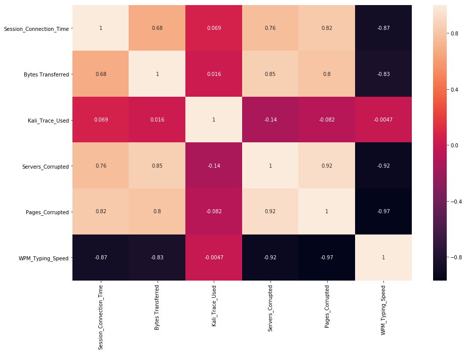

```python
plt.show()
```

```python
import pandas as pd
```

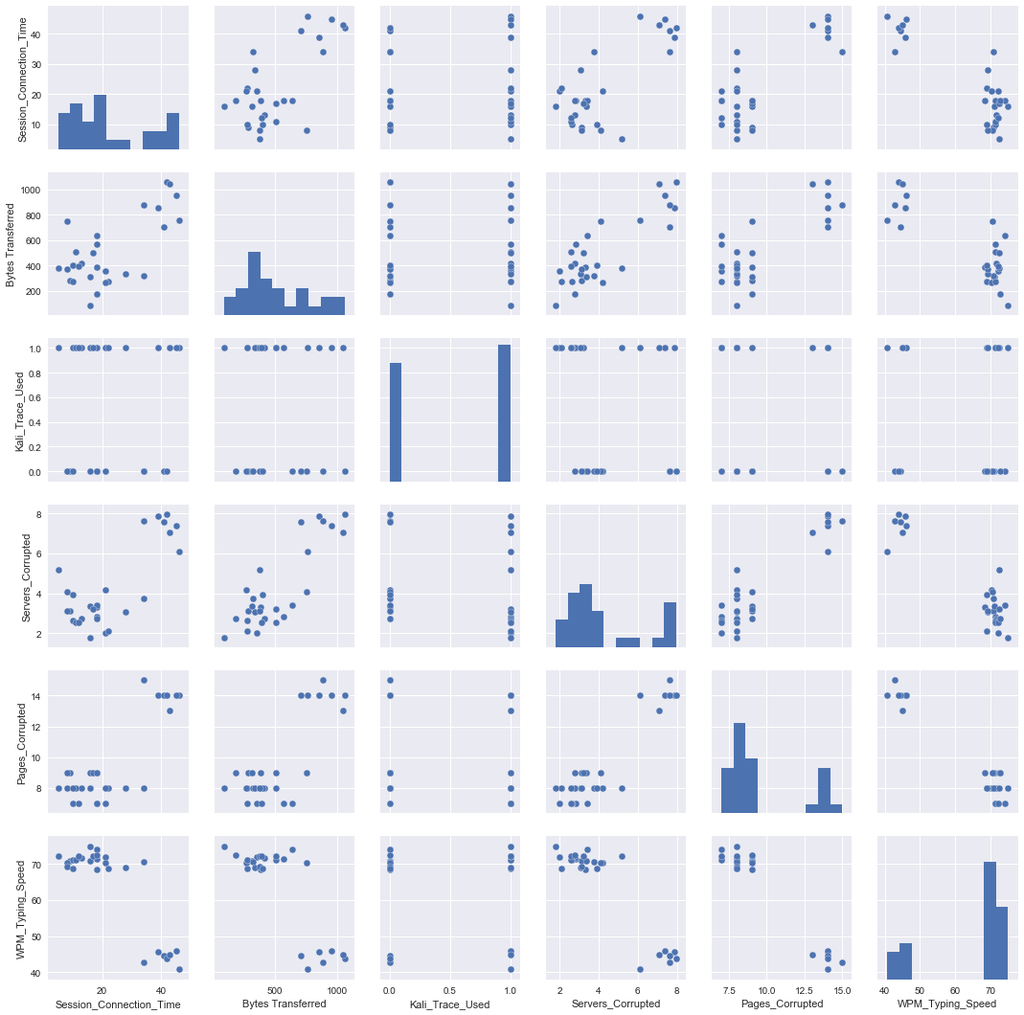

```python
sns.set()
cols = ['Session_Connection_Time',
        'Bytes Transferred',
        'Kali_Trace_Used',
        'Servers_Corrupted',
        'Pages_Corrupted',
        'WPM_Typing_Speed']
sns.pairplot(data_pd [cols], size = 2.5)
plt.show();
```

## Prepare the data for Clustering Model

For clustering, MLlib library in Spark accepts only the dataframes that have one column. This column should contain all the features in the form of vectors, with each vector corresponding to the features in that particular row.

After creating assembler, we transform our data to "assembled_data".

After transformation, our "assembled_data" will contain all the original attributes as well as the newly created attribute, called features.

```python
# Import VectorAssembler
from pyspark.ml.linalg import Vectors
from pyspark.ml.feature import VectorAssembler
```

```python
# Select the required attributes and store in "required_cols"
required_cols = data.select(['Session_Connection_Time',
                             'Bytes Transferred',
                             'Kali_Trace_Used',
                             'Servers_Corrupted',
                             'Pages_Corrupted',
                             'WPM_Typing_Speed'])
```

```python
# VectorAssembler is used to assemble all the attributes in the input column(required_cols) into single vector column called 'features'
assembler = VectorAssembler(inputCols = required_cols.columns, outputCol='features')
```

```python
# After transformation, assembled_data contains original attributes as well as new attribute "feature"
assembled_data = assembler.transform(data)
```

## Scale the data

Scaling also known as Normalization is used to standardize the data. StandardScaler in Spark is used to scale the data which contains two columns "inputCol" and "outputCol"

```python
# import StandardScaler
from pyspark.ml.feature import StandardScaler
```

```python
# StandScaler is used to  standardise data. It accepts two arguments "inputCol" and "outputCol"
scaler = StandardScaler(inputCol="features", outputCol="scaledFeatures", withStd=True, withMean=False)
```

```python
# Fit the scaler to assembled_data
scalerModel = scaler.fit(assembled_data)
```

```python
#  After transforming our data, the dataframe will contain the newly created scaledFeatures attribute along with the original attributes.
standarized_data = scalerModel.transform(assembled_data)
```

```python
# Show the scaled data
standarized_data.show()
```

```
+-----------------------+-----------------+---------------+-----------------+---------------+--------------------+----------------+--------------------+--------------------+
|Session_Connection_Time|Bytes Transferred|Kali_Trace_Used|Servers_Corrupted|Pages_Corrupted|            Location|WPM_Typing_Speed|            features|      scaledFeatures|
+-----------------------+-----------------+---------------+-----------------+---------------+--------------------+----------------+--------------------+--------------------+
|                    8.0|           391.09|              1|             2.96|            7.0|            Slovenia|           72.37|[8.0,391.09,1.0,2...|[0.56785108466505...|
|                   20.0|           720.99|              0|             3.04|            9.0|British Virgin Is...|           69.08|[20.0,720.99,0.0,...|[1.41962771166263...|
|                   31.0|           356.32|              1|             3.71|            8.0|             Tokelau|           70.58|[31.0,356.32,1.0,...|[2.20042295307707...|
|                    2.0|           228.08|              1|             2.48|            8.0|             Bolivia|            70.8|[2.0,228.08,1.0,2...|[0.14196277116626...|
|                   20.0|            408.5|              0|             3.57|            8.0|                Iraq|           71.28|[20.0,408.5,0.0,3...|[1.41962771166263...|
|                    1.0|           390.69|              1|             2.79|            9.0|    Marshall Islands|           71.57|[1.0,390.69,1.0,2...|[0.07098138558313...|
|                   18.0|           342.97|              1|              5.1|            7.0|             Georgia|           72.32|[18.0,342.97,1.0,...|[1.27766494049636...|
|                   22.0|           101.61|              1|             3.03|            7.0|         Timor-Leste|           72.03|[22.0,101.61,1.0,...|[1.56159048282889...|
|                   15.0|           275.53|              1|             3.53|            8.0|Palestinian Terri...|           70.17|[15.0,275.53,1.0,...|[1.06472078374697...|
|                   12.0|           424.83|              1|             2.53|            8.0|          Bangladesh|           69.99|[12.0,424.83,1.0,...|[0.85177662699757...|
|                   15.0|           249.09|              1|             3.39|            9.0|Northern Mariana ...|           70.77|[15.0,249.09,1.0,...|[1.06472078374697...|
|                   32.0|           242.48|              0|             4.24|            8.0|            Zimbabwe|           67.93|[32.0,242.48,0.0,...|[2.27140433866020...|
|                   23.0|           514.54|              0|             3.18|            8.0|         Isle of Man|           68.56|[23.0,514.54,0.0,...|[1.63257186841202...|
|                    9.0|           284.77|              0|             3.12|            9.0|Sao Tome and Prin...|           70.82|[9.0,284.77,0.0,3...|[0.63883247024818...|
|                   27.0|           779.25|              1|             2.37|            8.0|              Greece|           72.73|[27.0,779.25,1.0,...|[1.91649741074455...|
|                   12.0|           307.31|              1|             3.22|            7.0|     Solomon Islands|           67.95|[12.0,307.31,1.0,...|[0.85177662699757...|
|                   21.0|           355.94|              1|              2.0|            7.0|       Guinea-Bissau|            72.0|[21.0,355.94,1.0,...|[1.49060909724576...|
|                   10.0|           372.65|              0|             3.33|            7.0|        Burkina Faso|           69.19|[10.0,372.65,0.0,...|[0.70981385583131...|
|                   20.0|           347.23|              1|             2.33|            7.0|            Mongolia|           70.41|[20.0,347.23,1.0,...|[1.41962771166263...|
|                   22.0|           456.57|              0|             1.52|            8.0|             Nigeria|           69.35|[22.0,456.57,0.0,...|[1.56159048282889...|
+-----------------------+-----------------+---------------+-----------------+---------------+--------------------+----------------+--------------------+--------------------+
only showing top 20 rows
```

## K-Means Algorithm

#### To determine whether there were two hackers or three hackers involved in hacking, two K-means models are created with one model initialized K = 2 and other model with K = 3.

```python
# Build two models with K = 2 and K = 3
kmeans_k2 = KMeans(featuresCol='scaledFeatures', k=2)
kmeans_k3 = KMeans(featuresCol='scaledFeatures', k=3)
```

```python
# Fit the two models
model_k2 = kmeans_k2.fit(standarized_data)
model_k3= kmeans_k3.fit(standarized_data)
```

```python
# Show the results
centers = model_k2.clusterCenters()
print("Cluster Centers with K = 2:")
for center in centers:
        print(center)

centers = model_k3.clusterCenters()
print("Cluster Centers with K = 3:")
for center in centers:
        print(center)
```

```
Cluster Centers with K = 2:
[1.26023837 1.31829808 0.99280765 1.36491885 2.5625043  5.26676612]
[2.99991988 2.92319035 1.05261534 3.20390443 4.51321315 3.28474   ]
Cluster Centers with K = 3:
[1.30217042 1.25830099 0.         1.35793211 2.57251009 5.24230473]
[2.99991988 2.92319035 1.05261534 3.20390443 4.51321315 3.28474   ]
[1.21780112 1.37901802 1.99757683 1.37198977 2.55237797 5.29152222]
```

### Model Prediction when K = 3

When K = 3, the number of instances are not equally divided among three clusters. This goes against the facr that when group of hackers work together, they often divide the attacks equally.

So, there are very less chances that third hacker involved in attack.

```python
# Prediction column contain integers that indicate the cluster to which each attack instance has been classified.
print("Prediction of results when number of clusters equal to three:")
model_k3_data = model_k3.transform(standarized_data)
model_k3_data.groupBy('prediction').count().show()
```

```
Prediction of results when number of clusters equal to three:
+----------+-----+
|prediction|count|
+----------+-----+
|         1|  167|
|         2|   83|
|         0|   84|
+----------+-----+
```

### Model Prediction when K = 2

With K=2, both clusters here have exactly the same number of instances assigned to them. When group of hackers work together, they often divide the attacks equally. Therefore, we conclude that only two hackers were involved with the attack.

So, third hacker is not involved in attack

```python
# Prediction column contain integers that indicate the cluster to which each attack instance has been classified.
print("Prediction of results when number of clusters equal to two:")
model_k2_data = model_k2.transform(standarized_data)
model_k2_data.groupBy('prediction').count().show()
```

```
Prediction of results when number of clusters equal to two:
+----------+-----+
|prediction|count|
+----------+-----+
|         1|  167|
|         0|  167|
+----------+-----+
```

## Evaluate the model

The model is evaluated using following metrics:

1. Within set sum of Squared Errors(WSSE)
2. Silhouette_score

```python
# Evaluate clustering by computing within set sum of Squared Errors
print("For cluster with K = 2:")
wssse = model_k2.computeCost(model_k2_data)
print("Within set sum of Squared Errors = " + str(wssse))

print("For cluster with K = 3:")
wssse = model_k3.computeCost(model_k3_data)
print("Within set sum of Squared Errors = " + str(wssse))
```

```
For cluster with K = 2:
Within set sum of Squared Errors = 601.7707512676716
For cluster with K = 3:
Within set sum of Squared Errors = 434.1492898715845
```

```python
# Evaluate clustering by computing silhouette_score

from pyspark.ml.evaluation import ClusteringEvaluator
evaluator = ClusteringEvaluator()

print("For cluster with K = 2:")
silhouette = evaluator.evaluate(model_k2_data)
print("Silhouette with squared euclidean distance:" + str(silhouette))

print("Cluster with K = 3:")
silhouette = evaluator.evaluate(model_k3_data)
print("Silhouette with squared euclidean distance:" + str(silhouette))
```

```
For cluster with K = 2:
Silhouette with squared euclidean distance:0.6683623593283755
Cluster with K = 3:
Silhouette with squared euclidean distance:0.3068084951287429
```

## Conclusion

When K = 2, the clusters contains equal number of instances so we conclude that third hacker is not involved in hacking.